# Reporting VS Analytics - Knowing the difference as a Data Analyst

Confidential: Property of the Data Jedi Academy, unauthorised distribution not allowed

[figure not shown]

### Reporting VS Analytics

Reporting refers to creating information based on raw data pulled from a data source. This information can be in the form of tables, charts etc. The raw data used is typically pulled from a company's operational database, their website's or even third party applications.

Analytics is used to refer to the act of analyzing information to obtain actionable insight. In other words, the process of analytics is used to answer deeper questions about the initial report.

Without reporting, a business owner simply wouldn't be able to analyze their data. And without analytics, reporting simply wouldn't provide any real insight to the business owner.

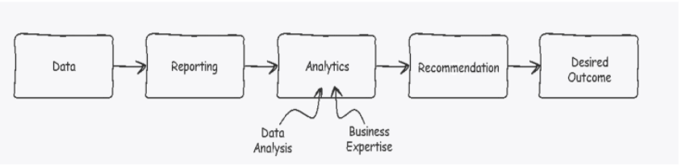

In other words, reporting simply provides business owners and managers with a summarized version of an organisation’s raw data. Reporting basically provides the numbers that can be analyzed later on.

For example, a company can get a report on its financial performance such as total revenue, total profit, trend of revenue per month etc. These basically sit under reporting even though some aggregation and collation needs to be done to provide these reports. On the other hand, analytics will be focused more on analysing these summarised numbers to understand the why and how. For example, revenue per product to identify products that are responsible for the revenue. Identify if revenue increased or dropped from previous periods and why etc. With analytics you dive into the details to get insights that can guide decision making and answer deeper questions.

To summarize the difference; reporting is used to translate raw data into information, while analytics is used to draw insight from that information, helping business owners and managers truly understand their customer relationships, as well as how they can provide better products and services in the future.

[Reporting VS Analytics](https://zipreporting.com/en/analytical-report/.html)

### Key Differences

Reporting is typically easier to do compared to analytics. This is why many organisations stop at reporting without delving deeper through analytics. Reporting is valuable however, it doesn’t provide a complete picture for decision making which is why analytics is required. Analytics drives business decisions by questioning and interpreting the data with a distinct purpose in mind. Analytics go beyond summaries and “what happened” and seek to answer “why it happened” and “what can be done about it.”

We will delve into some more differences below:

#### Tasks Involved

- Reporting involves tasks such as organizing, summarizing and visualizing the data in tables, charts and dashboards to make it easier to understand. On the other hand, analytics involves questioning the information to find out “why”,”how” and “what can be done about it”. Therefore, common analytics tasks include comparing, interpreting, and understanding trends or forecasts pulled from the report.

#### Reason for Each

- Reporting informs organisations about their operations but on a summarised level. This includes getting information on total revenue, total expenses, number of customers etc. However, analytics helps to interpret this information at a significantly deeper level to provide actionable insights and recommendations on what the organisation needs to do in the present or future.

#### Value

- Reporting and analytics are both useful however, reporting without analytics doesn’t provide significant value for decision making. Reporting provides organisations with the value of being able to understand their data, however, analytics provides them with the value of knowing what they can do in the future based on the analysed data.

[Differences between Reporting and Analytics](https://accent-technologies.com/2017/04/28/reporting-vs-analytics-whats-difference/)

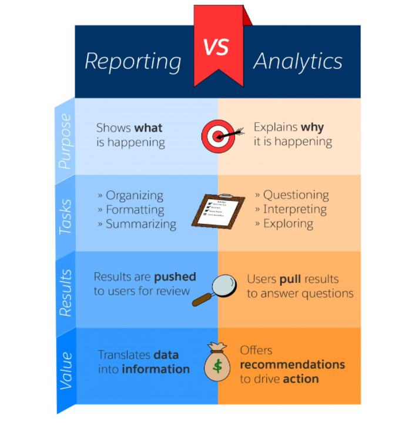